# Verhalten des 95% Konfidenzintervalls

Marcel Miché

2026-04-24

## Wie verhält sich das 95% Konfidenzintervall?

### Einleitung

**Hauptfrage**: Wie verhält sich das zweiseitige 95% Konfidenzintervall (95% KI)?

Diese Frage wird unabhängig von jeglichen theoretischen Aspekten behandelt, die man beim 95% KI betrachten könnte. Es geht also lediglich um das zahlenmässige Verhalten des 95% KI, d.h. unter welchen Bedingungen (siehe Reiter *Drei Bedingungen*) verändert sich dessen Breite? Mit Breite ist die Distanz gemeint zwischen unterer und oberer 95% KI Grenze.

Es wird der Output eines einfachen linearen Regressionsmodells genommen, d.h. das Regressionsgewicht (Estimate), dessen Standardfehler (StdError), die t-Statistik (= Estimate/StdError), dessen p-Wert und dessen zweiseitiges 95% KI.

**Hinweis**: Der Inhalt dieser html Datei als R-Skript (behaviorOf95PercentCI.R) kann von [hier](https://github.com/mmiche/GitHubHowTo) runtergeladen werden.

### Vorbereitung

Vorab, zwei eigene Funktionen:

```r
# Eigens geschriebene Funktion, um 2-seitigen p-Wert korrekt zu berechnen.
# Notiz: Abhängig davon, ob Regressionsgewicht negativ oder positiv ist, muss man in der Funktion qt() das Argument lower.tail auf TRUE belassen oder es zu FALSE ändern.
pValFun <- function(tValue=NULL, df=NULL) {
    if(tValue < 0) {
        return(pt(q=tValue, df=df)*2)
    } else {
        return(pt(q=tValue, df=df, lower.tail = FALSE)*2)
    }
}
```

```r
# Eigens geschriebene  Funktion, die die t-Statistik, den p-Wert und das 95% KI berechnet.
manualComputation <- function(data=NULL, percent=.95, df=NULL) {
    # Berechne t-Statistik
    tVals <- data[,"Estimate"]/data[,"StdError"]
    # Berechne 2-seitigen p-Wert
    pVals <- c()
    for(i in 1:length(tVals)) {
        pVals <- c(pVals, pValFun(tValue=tVals[i], df=df))
    }
    # Ermittle kritischen 2-seitigen Wert unter t-Verteilung
    crit <- qt((1-percent)/2, df=df, lower.tail = FALSE)
    # left = untere Grenze des CI
    left <- data[,"Estimate"] - crit * data[,"StdError"]
    # right = obere Grenze des CI
    right <- data[,"Estimate"] + crit * data[,"StdError"]
    # out = Alle Ergebnisse als data.frame ausgeben.
    out <- data.frame(
        Estimate=data[,"Estimate"],
        StdError=data[,"StdError"],
        tValue=tVals,
        pValue=pVals,
        lowerCI=left,
        upperCI=right
    )
    return(out)
}
```

### Drei Bedingungen

Wie verhält sich das 95% Konfidenzinterval (95% KI), unter diesen drei Bedingungen?

1. Fixiert seien das Regressionsgewicht und die Freiheitsgrade, der Standardfehler wird verändert.
2. Fixiert seien der Standardfehler und die Freiheitsgrade, das Regressionsgewicht wird verändert.
3. Fixiert seien das Regressionsgewicht und der Standardfehler, die Freiheitsgrade werden verändert.

Zeile 1 des Output sei Referenzwert, darauf folgen 3 kleinere und dann 3 grössere Werte. Man beachte wie sich die Distanzen im Vergleich zum Referenzwert verändern.

### Bedingung 1

> Fixiert: Regressionsgewicht, Freiheitsgrade. Variiert: Standardfehler.

```r
output1 <- data.frame(Estimate=.5,
                      StdError=c(.2, .15, .1, .05, .25, .3, .45))
(ergebnis1 <- manualComputation(data=output1, df=62))
```

```
##   Estimate StdError    tValue       pValue       lowerCI   upperCI
## 1      0.5     0.20  2.500000 1.507889e-02  0.1002056966 0.8997943
## 2      0.5     0.15  3.333333 1.451260e-03  0.2001542724 0.7998457
## 3      0.5     0.10  5.000000 4.992796e-06  0.3001028483 0.6998972
## 4      0.5     0.05 10.000000 1.492156e-14  0.4000514241 0.5999486
## 5      0.5     0.25  2.000000 4.988584e-02  0.0002571207 0.9997429
## 6      0.5     0.30  1.666667 1.006253e-01 -0.0996914551 1.0996915
## 7      0.5     0.45  1.111111 2.708109e-01 -0.3995371827 1.3995372
```

```r
# Berechne 'Distanz' zwischen unterer und oberer Grenze des 95% KI:
(distanz1 <- apply(ergebnis1[,5:6], 1, dist))
```

```
## [1] 0.7995886 0.5996915 0.3997943 0.1998972 0.9994858 1.1993829 1.7990744
```

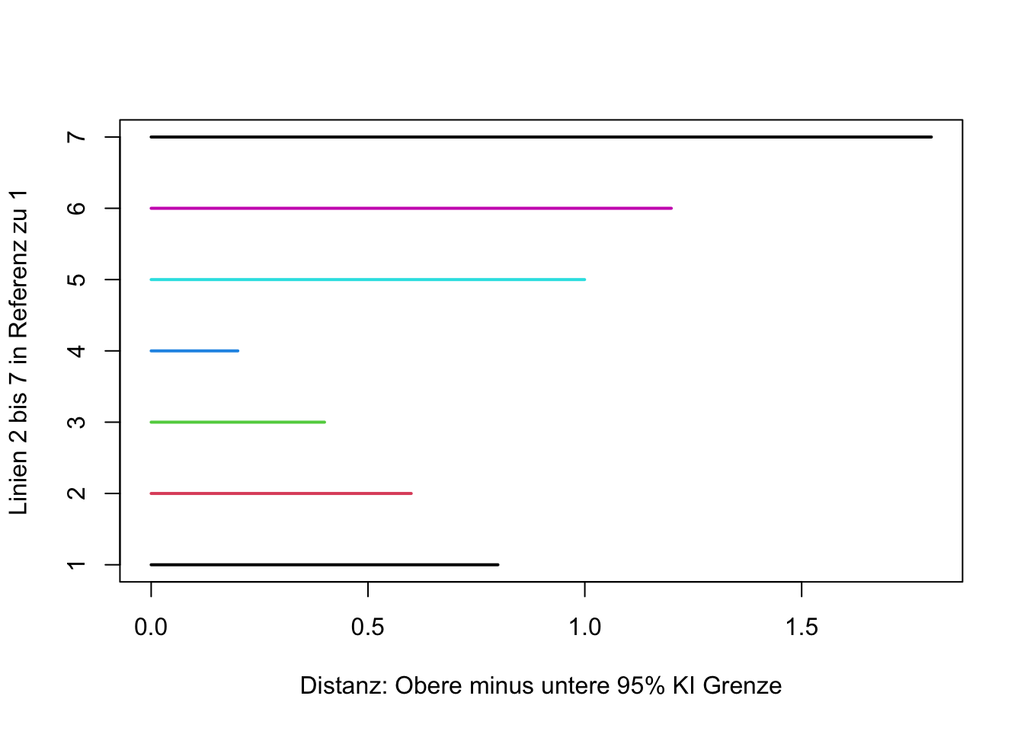

```r
# Antwort: Immer verglichen mit Zeile 1, bei:
# Verkleinerung des StdError = 95% KI wird enger (= präziser)
# Vergrösserung des StdError = 95% KI wird breiter (= unpräziser)
# Visualisierung:
mat1 <- rbind(x=rep(0, 7), distanz1)
matplot(y=rbind(1:7, 1:7), x=mat1, type="l", lty=1, lwd=2,
        xlab = "Distanz: Obere minus untere 95% KI Grenze",
        ylab = "Linien 2 bis 7 in Referenz zu 1")
```

### Bedingung 2

> Fixiert: Standardfehler, Freiheitsgrade. Variiert: Regressionsgewicht.

```r
output2 <- data.frame(Estimate=c(.5, .45, .4, .3, .55, .6, .7),
                      StdError=.2)
(ergebnis2 <- manualComputation(data=output2, df=62))
```

```
##   Estimate StdError tValue       pValue       lowerCI   upperCI
## 1     0.50      0.2   2.50 0.0150788905  0.1002056966 0.8997943
## 2     0.45      0.2   2.25 0.0280077515  0.0502056966 0.8497943
## 3     0.40      0.2   2.00 0.0498858393  0.0002056966 0.7997943
## 4     0.30      0.2   1.50 0.1386897547 -0.0997943034 0.6997943
## 5     0.55      0.2   2.75 0.0077997000  0.1502056966 0.9497943
## 6     0.60      0.2   3.00 0.0038843799  0.2002056966 0.9997943
## 7     0.70      0.2   3.50 0.0008677675  0.3002056966 1.0997943
```

```r
# Berechne 'Distanz' zwischen unterer und oberer Grenze des 95% KI:
(distanz2 <- apply(ergebnis2[,5:6], 1, dist))
```

```
## [1] 0.7995886 0.7995886 0.7995886 0.7995886 0.7995886 0.7995886 0.7995886
```

```r
# Als Spalte präsentiert:
cbind(distanz2)
```

```
##       distanz2
## [1,] 0.7995886
## [2,] 0.7995886
## [3,] 0.7995886
## [4,] 0.7995886
## [5,] 0.7995886
## [6,] 0.7995886
## [7,] 0.7995886
```

```r
# Antwort:
# Das 95% KI bleibt konstant breit.
```

### Bedingung 3

> Fixiert: Regressionsgewicht, Standardfehler. Variiert: Freiheitsgrade.

```r
output3 <- data.frame(Estimate=.5, StdError=.2)
(ergebnis3 <- manualComputation(data=output3,
                                df=c(6, 5, 4, 3, 7, 8, 9)))
```

```
##   Estimate StdError tValue     pValue     lowerCI   upperCI
## 1      0.5      0.2    2.5 0.04652823  0.01061763 0.9893824
## 2      0.5      0.2    2.5 0.05449010 -0.01411637 1.0141164
## 3      0.5      0.2    2.5 0.06676654 -0.05528902 1.0552890
## 4      0.5      0.2    2.5 0.08770665 -0.13648926 1.1364893
## 5      0.5      0.2    2.5 0.04099222  0.02707515 0.9729249
## 6      0.5      0.2    2.5 0.03694204  0.03879917 0.9612008
## 7      0.5      0.2    2.5 0.03386183  0.04756857 0.9524314
```

```r
# Berechne 'Distanz' zwischen unterer und oberer Grenze des 95% KI:
(distanz3 <- apply(ergebnis3[,5:6], 1, dist))
```

```
## [1] 0.9787647 1.0282327 1.1105780 1.2729785 0.9458497 0.9224017 0.9048629
```

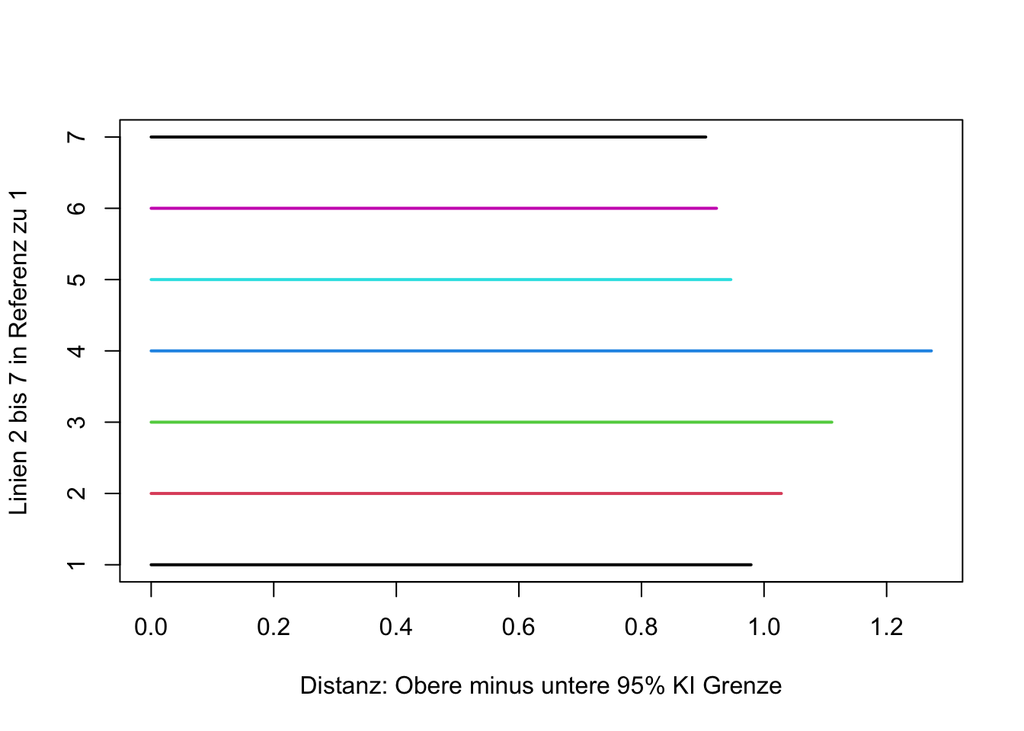

```r
# Antwort:
# Verkleinerung der Freiheitsgrade = 95% KI wird breiter (= unpräziser)
# Vergrösserung des Freiheitsgrade = 95% KI wird enger (= präziser)
#
# Visualisierung:
mat3 <- rbind(x=rep(0, 7), distanz3)
matplot(y=rbind(1:7, 1:7), x=mat3, type="l", lty=1, lwd=2,
        xlab = "Distanz: Obere minus untere 95% KI Grenze",
        ylab = "Linien 2 bis 7 in Referenz zu 1")
```

### Lesehinweise

Wer an theoretischen Aspekten rund um das (frequentistische) 95% Konfidenzintervall Interesse hat, siehe ‘Can Confidence Intervals Be Interpreted?’ von Naimi & Whitcomb (2020) sowie der Enzyklopädieeintrag ‘Confidence Interval’ von Smithson (2025).

Sehr nahe verwandt ist der weit verbreitete Irrglaube, demzufolge zwei überlappende, unabhängige Konfidenzintervalle immer anzeigen, dass sich beide Gruppen statistisch nicht signifikant voneinander unterscheiden. Zur Einsicht reicht das Abstract von Cumming (2009).

Wer wissen will, welche und wie viel Information in einem Konfidenzintervall enthalten ist, siehe ‘Beyond the confidence interval’ von Poole (1987) und/oder Poole (2001).

**Referenzen**

Cumming, G. (2009). Inference by eye: Reading the overlap of independent confidence intervals. *Statistics in medicine*, *28*(2), 205-220.

Naimi, A. I., & Whitcomb, B. W. (2020). Can confidence intervals be interpreted?. *American Journal of Epidemiology*, *189*(7), 631-633.

Poole, C. (1987). Beyond the confidence interval. *American Journal of Public Health*, *77*(2), 195-199.

Poole, C. (2001). Low P-values or narrow confidence intervals: which are more durable?. *Epidemiology*, 12(3), 291-294.

Smithson, M. (2025). Confidence interval. In *International Encyclopedia of Statistical Science* (pp. 516-518). Berlin, Heidelberg: Springer Berlin Heidelberg.